# MTH6139 Time Series

Forecasting Average Global Temperatures

Musa Latif

March 2024

### The purpose of my project is to observe the trend of average global surface temperatures

It is commonly known that the average global temperature is directly correlated to global warming hence forecasting temperatures 10 years from now may provide insight into the rapidly changing state of the world. To do this I will be using a forecasting tool called Prophet, created by Meta.

https://facebook.github.io/prophet/docs/quick_start.html#r-api - Guide on Meta

```r
library("prophet")
library(readxl)
Monthly_Average_Temp <- read_excel("~/Downloads/Monthly Average Temp.xlsx")
Averagetemperature.dataframe <- data.frame(
  ds = as.Date(Monthly_Average_Temp$Date),
  y = Monthly_Average_Temp$'Monthly Mean Temperature'
)
```

First, I called the function library which contains the forecasting tool, prophet. Because I used my own data set, I had to call it from an external excel file. I then stored the data set in the variable Monthly_Average_Temp. Following this, I created the data frame called Averagetemperature.dataframe. My dates from my dataset are then assigned to the date stamp called ds and my average global temperatures are assigned to y representing the data that I want to be forecasted.

```r
average_model = prophet::prophet(Averagetemperature.dataframe, changepoint.prior.scale = 0.05, weekly.seasonality = TRUE, daily.seasonality = TRUE)
```

The prophet function is called again and a forecasting model is created using the dates and historical data stored in Averagetemperature.dataframe. The change point scale changes the flexibility in the change point. Change point is the point where there is a significant change (spike) in the data points which will be shown more clearly in the graphs later on.

```r
future_year = prophet::make_future_dataframe(average_model, periods=15, freq="year")
tail(future_year)
```

```
##             ds
## 334 2026-12-01
## 335 2027-12-01
## 336 2028-12-01
## 337 2029-12-01
## 338 2030-12-01
## 339 2031-12-01
```

```r
future_month = prophet::make_future_dataframe(average_model, periods=36, freq="month")
tail(future_month)
```

```
##             ds
## 355 2019-07-01
## 356 2019-08-01
## 357 2019-09-01
## 358 2019-10-01
## 359 2019-11-01
## 360 2019-12-01
```

These next few lines of code will create a new data frame storing future dates. I had a little mess around with the different frequencies to see how the forecast displayed on the graph can change. The periods give me the authority to set how long I want the data to be predicted for. I personally chose 15 years for one and 36 months for the other. I added the function tail to display the last 6 dates of the forecast. This is only really useful for post-analysis of the results.

```r
prediction_year = predict(average_model,future_year)
prediction_month = predict(average_model, future_month)
```

The predict function is important since this creates the future data values which will be assigned to their corresponding future dates. Essentially this completes the forecast and all that’s now left to do is to plot the data.

This next piece of code now plots the historical and future data points within the time frame I selected, specified in my code earlier.

### Yearly Plot

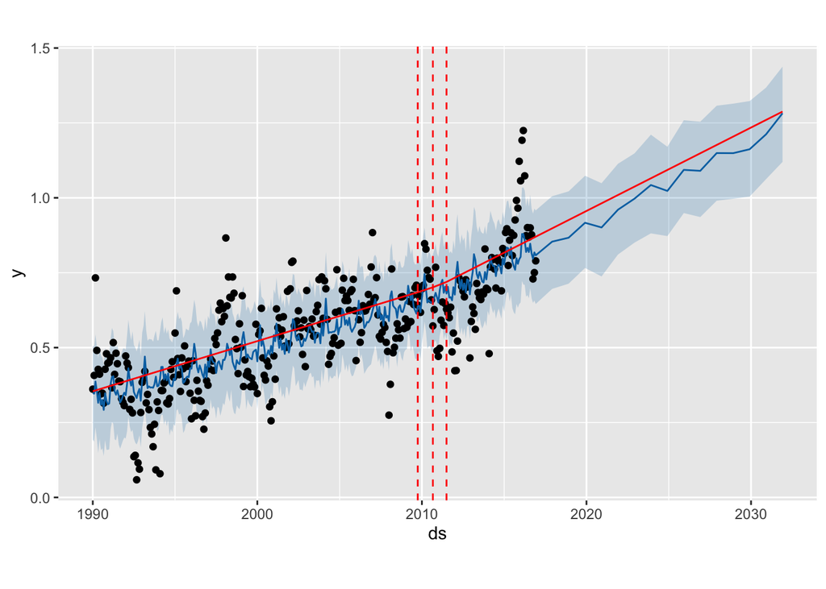

```r
plot(average_model,prediction_year) + add_changepoints_to_plot(average_model)
```

```r
dyplot.prophet(average_model, prediction_year)
```

[interactive chart not shown]

The frequency of this graph is set to year and shows the yearly change in average global temperatures. I wanted this graph to forecast the next 15 years.

### Monthly Plot

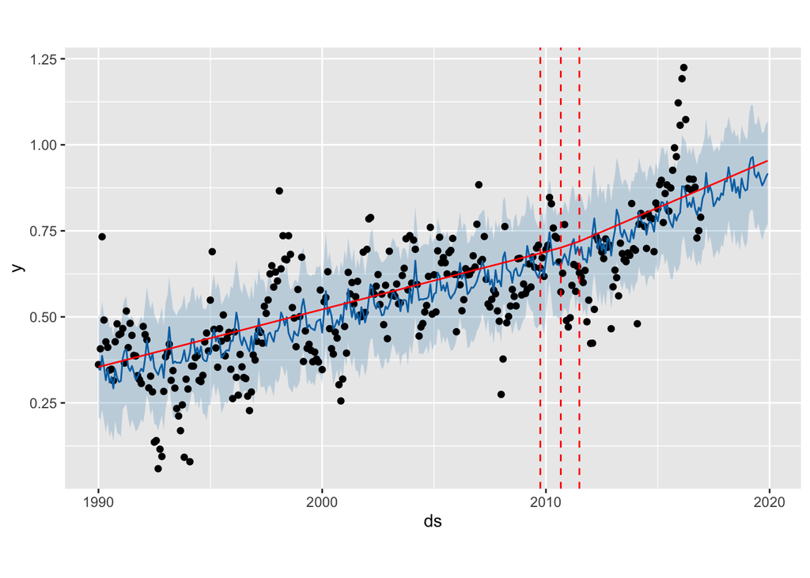

```r
plot(average_model,prediction_month) + add_changepoints_to_plot(average_model)
```

```r
dyplot.prophet(average_model, prediction_month)
```

[interactive chart not shown]

The frequency for this graph is set to month and this graph shows the monthly change in average global temperatures. I wanted this graph to plot 36 months of future data at smaller intervals than the yearly graph.

Change points are also added to signify large jumps between my data. These can give insight as to whether some external event has occurred causing the global average temperature to rise. The most likely cause of this is human involvement and is explained later in the article.

dyplot.prophet is very useful because it allows a viewer to interact with the graph and at a certain point you are able to view the future values for example, you are able to check the average global temperature in 2026 if you are interested simply by hovering over the graph.

### Seasonality

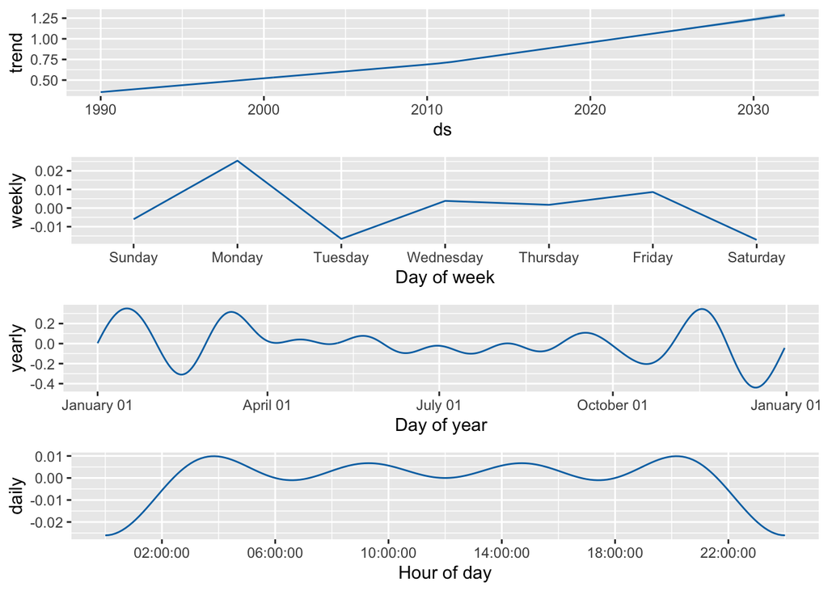

```r
prophet_plot_components(average_model,prediction_year)
```

This shows the daily, weekly and yearly seasonality. It also shows the overall trend of the three graphs.

### Describing the Trend

As seen from the graphs provided, the average global surface temperature of the earth is predicted to rise at a fairly constant rate and the date and average temperature is positively correlated. This is backed up by the trend for seasonality being a linear positive correlation as well. This indicates that global warming may be rising as a result of several factors. One major factor is increased greenhouse emissions. As we become more industrialized, we release more harmful gases which eventually harm the atmosphere. Another significant sign pointing to this is that the change points all lie around 2010.

https://climate.nasa.gov/news/467/nasa-research-finds-2010-tied-for-warmest-year-on-record/

https://www.climate.gov/news-features/climate-qa/hasnt-earth-warmed-and-cooled-naturally-throughout-history#

This article states that the Earth may be naturally warming anyway. So it is better to look at longer time periods as well the extreme data values (outliers).